# Value at Risk (VaR) — Monte Carlo Simulation Method

This notebook computes **Value at Risk (VaR)** using a **Monte Carlo simulation** approach.

## What you will do

- Choose a stock ticker (e.g., `AAPL`, `MSFT`, `NVDA`).
- Download daily **Adjusted Close** prices.
- Compute daily **simple returns**.
- Estimate return parameters from historical data.
- Simulate future returns under a parametric model (Normal i.i.d.).
- Compute **Monte Carlo VaR** for:
  - **Daily horizon**
  - **Multi‑day horizon** (e.g., 30 days)

## Key idea (Monte Carlo VaR)

Rather than computing VaR analytically, we:

1. Assume a data‑generating process for returns (here: Normal i.i.d.).
2. Simulate many possible outcomes (or paths).
3. Estimate VaR as the empirical lower‑tail quantile of simulated returns.

> **Convention used here:** VaR is reported as a **negative return** (loss threshold). Dollar VaR is therefore typically negative as well.

```python
# =========================
# 0) Imports
# =========================
import numpy as np
import pandas as pd
import yfinance as yf
import matplotlib.pyplot as plt

pd.set_option("display.width", 140)
pd.set_option("display.max_columns", 60)
```

## 1) Inputs

- **TICKER**: stock symbol
- **START, END**: sample window
- **CONF_LEVELS**: VaR confidence levels
- **INITIAL_INV**: portfolio value (for dollar VaR)
- **HORIZON_DAYS**: multi‑day VaR horizon
- **N_SIM**: number of Monte Carlo simulations

> Keep these inputs consistent across the Historical / Parametric / Monte Carlo VaR notebooks so results are comparable.

```python
# =========================
# 1) User inputs (edit these)
# =========================
TICKER = "NVDA"
START = "2021-01-01"
END   = "2025-12-31"

CONF_LEVELS = [0.95, 0.99]
INITIAL_INV = 100000
HORIZON_DAYS = 30
N_SIM = 100_000

TICKER, START, END, CONF_LEVELS, INITIAL_INV, HORIZON_DAYS, N_SIM
```

```
('NVDA', '2021-01-01', '2025-12-31', [0.95, 0.99], 100000, 30, 100000)
```

## 2) Download data and compute returns

We use **simple daily returns** for consistency with the other VaR methods.

```python
# =========================
# 2) Download price data and compute returns
# =========================
raw = yf.download(TICKER, start=START, end=END, progress=False, auto_adjust=False)

if raw.empty:
    raise ValueError(f"No data returned for ticker {TICKER}. Check the symbol and date range.")

df = raw[["Adj Close"]].rename(columns={"Adj Close": "adj_close"}).copy()
df["simple_rtn"] = df["adj_close"].pct_change()
df = df.dropna()

df.head()
```

| Price Ticker Date | adj_close NVDA | simple_rtn |
| --- | --- | --- |
| 2021-01-05 | 13.335953 | 0.022210 |
| 2021-01-06 | 12.549760 | -0.058953 |
| 2021-01-07 | 13.275517 | 0.057830 |
| 2021-01-08 | 13.208609 | -0.005040 |
| 2021-01-11 | 13.551590 | 0.025967 |

## 3) Estimate return parameters

We estimate the mean and volatility of daily returns and use them as inputs for the simulation model:

- (\hat\mu): sample mean of daily returns
- (\hat\sigma): sample standard deviation of daily returns

```python
# =========================
# 3) Parameter estimates
# =========================
mu_hat = df["simple_rtn"].mean()
sigma_hat = df["simple_rtn"].std(ddof=1)

pd.DataFrame({
    "Parameter": ["mu_hat (daily mean)", "sigma_hat (daily std dev)"],
    "Value": [mu_hat, sigma_hat]
})
```

|  | Parameter | Value |
| --- | --- | --- |
| 0 | mu_hat (daily mean) | 0.002663 |
| 1 | sigma_hat (daily std dev) | 0.032911 |

## 4) Monte Carlo simulation — Daily VaR

We simulate **daily returns** from the assumed distribution and compute VaR as the empirical lower‑tail quantile of simulated returns.

```python
# =========================
# 4) Simulate daily returns
# =========================
rng = np.random.default_rng(42)  # reproducibility
sim_daily = rng.normal(loc=mu_hat, scale=sigma_hat, size=N_SIM)

# Compute daily VaR (return and $)
results_daily = []
for c in CONF_LEVELS:
    alpha = 1 - c
    var_r = np.percentile(sim_daily, 100 * alpha)
    var_usd = INITIAL_INV * var_r

    results_daily.append({
        "Confidence": f"{int(c*100)}%",
        "Daily VaR (return)": var_r,
        "Daily VaR ($)": var_usd
    })

daily_table = pd.DataFrame(results_daily)
daily_table
```

|  | Confidence | Daily VaR (return) | Daily VaR ($) |
| --- | --- | --- | --- |
| 0 | 95% | -0.051914 | -5191.419588 |
| 1 | 99% | -0.074464 | -7446.350286 |

### Daily VaR visualization

A histogram makes the VaR interpretation clear: the vertical lines mark the left‑tail quantiles corresponding to the chosen confidence levels.

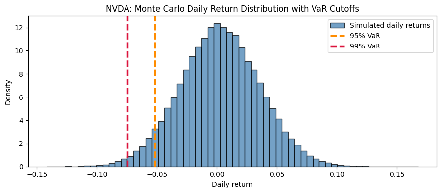

```python
# =========================
# Histogram with VaR cutoffs (Monte Carlo – Daily)
# =========================
plt.figure(figsize=(9,4))
plt.hist(
    sim_daily,
    bins=60,
    density=True,
    edgecolor="black",
    alpha=0.75,
    color="steelblue",
    label="Simulated daily returns"
)

# VaR lines with different colors
colors = {0.95: "darkorange", 0.99: "crimson"}

for c in CONF_LEVELS:
    alpha = 1 - c
    var_r = np.percentile(sim_daily, 100 * alpha)
    plt.axvline(
        var_r,
        linestyle="--",
        linewidth=2.5,
        color=colors[c],
        label=f"{int(c*100)}% VaR"
    )

plt.title(f"{TICKER}: Monte Carlo Daily Return Distribution with VaR Cutoffs")
plt.xlabel("Daily return")
plt.ylabel("Density")
plt.legend()
plt.tight_layout()
plt.show()
```

## 5) Monte Carlo simulation — Horizon VaR

To compute horizon VaR, we simulate **paths** of daily returns and compound them to form horizon returns:

[ R_{t,t+H} = \prod_{j=1}^{H} (1 + R_{t+j}) - 1 ]

VaR is computed from the simulated horizon‑return distribution.

```python
# =========================
# 5) Simulate return paths and compute horizon returns
# =========================
# Simulate daily return paths: shape = (N_SIM, HORIZON_DAYS)
sim_paths = rng.normal(loc=mu_hat, scale=sigma_hat, size=(N_SIM, HORIZON_DAYS))

# Compound returns along each path to get H-day return
sim_horizon = np.prod(1 + sim_paths, axis=1) - 1

# Compute horizon VaR (return and $)
results_h = []
for c in CONF_LEVELS:
    alpha = 1 - c
    var_h = np.percentile(sim_horizon, 100 * alpha)
    var_h_usd = INITIAL_INV * var_h

    results_h.append({
        "Confidence": f"{int(c*100)}%",
        f"{HORIZON_DAYS}-day VaR (return)": var_h,
        f"{HORIZON_DAYS}-day VaR ($)": var_h_usd
    })

horizon_table = pd.DataFrame(results_h)
horizon_table
```

|  | Confidence | 30-day VaR (return) | 30-day VaR ($) |
| --- | --- | --- | --- |
| 0 | 95% | -0.207110 | -20711.011369 |
| 1 | 99% | -0.301794 | -30179.382632 |

### Horizon VaR visualization (recommended)

This histogram shows the simulated distribution of **H‑day compounded returns** and the VaR cutoffs.

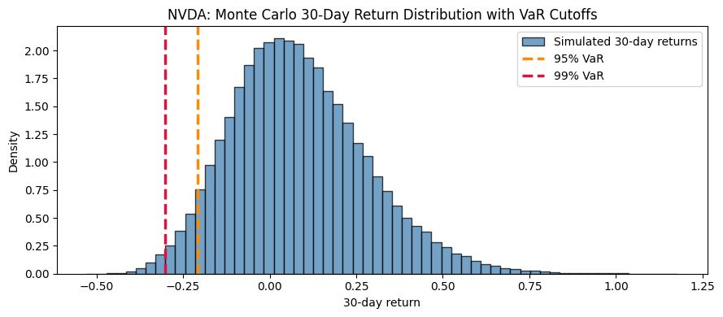

```python
# =========================
# Histogram with VaR cutoffs (Monte Carlo – Horizon)
# =========================
plt.figure(figsize=(9,4))

# Histogram of simulated horizon returns
plt.hist(
    sim_horizon,
    bins=60,
    density=True,
    edgecolor="black",
    alpha=0.75,
    color="steelblue",
    label=f"Simulated {HORIZON_DAYS}-day returns"
)

# VaR line colors
colors = {0.95: "darkorange", 0.99: "crimson"}

for c in CONF_LEVELS:
    alpha = 1 - c
    var_h = np.percentile(sim_horizon, 100 * alpha)
    plt.axvline(
        var_h,
        linestyle="--",
        linewidth=2.5,
        color=colors[c],
        label=f"{int(c*100)}% VaR"
    )

plt.title(f"{TICKER}: Monte Carlo {HORIZON_DAYS}-Day Return Distribution with VaR Cutoffs")
plt.xlabel(f"{HORIZON_DAYS}-day return")
plt.ylabel("Density")
plt.legend()
plt.tight_layout()
plt.show()
```

## 6) Interpretation prompts (optional)

- Compare Monte Carlo VaR to Parametric VaR. Why are they often similar here?
- How would Monte Carlo VaR change if you simulated fat‑tailed returns instead of Normal?
- Why might horizon VaR be much larger in magnitude than daily VaR?

## Appendix: Exporting your notebook (for submission)

To export with outputs visible (so the instructor does not need to re-run code):

- **HTML**: File → Save and Export Notebook As → HTML
- **PDF**: File → Save and Export Notebook As → PDF *(may require LaTeX installed)*

# Python Exercise #2 — Written Answers (Q1–Q5)

**Siqi He · Investment Data Analytics · NVDA**

All three notebooks use NVDA adjusted closing prices, START = 2021-01-01, END = 2025-12-31 (exclusive), a USD 100,000 investment, 95% and 99% confidence levels, and a 30-trading-day horizon. Monte Carlo uses 100,000 simulations and random seed 42. The tables below summarize the executed notebook outputs. Returns are signed loss thresholds; dollar losses are shown as positive magnitudes for readability.

| Method | Confidence | Daily return threshold | Daily loss magnitude | 30-day return threshold | 30-day loss magnitude |
| --- | --- | --- | --- | --- | --- |
| Historical | 95% | −4.8350% | USD 4,835.04 | −20.9651% | USD 20,965.06 |
| Historical | 99% | −7.6101% | USD 7,610.08 | −33.1554% | USD 33,155.42 |
| Parametric (Normal) | 95% | −5.1470% | USD 5,147.01 | −21.6603% | USD 21,660.27 |
| Parametric (Normal) | 99% | −7.3899% | USD 7,389.86 | −33.9449% | USD 33,944.86 |
| Monte Carlo | 95% | −5.1914% | USD 5,191.42 | −20.7110% | USD 20,711.01 |
| Monte Carlo | 99% | −7.4464% | USD 7,446.35 | −30.1794% | USD 30,179.38 |

## Q1. What does VaR measure?

Value at Risk is a loss threshold for a specified holding period and confidence level. For example, Historical 95% daily VaR for this USD 100,000 NVDA position is a return threshold of −4.8350%, or a loss of USD 4,835.04. If the historical distribution remains representative, about 5% of daily outcomes would be worse than this threshold, while about 95% would not. At 99% confidence, the estimated daily loss threshold rises to USD 7,610.08, with a 1% probability of a worse outcome under the estimated distribution.

VaR does not give the maximum possible loss or the average loss in the worst cases. It says nothing about how severe a loss will be once the threshold is exceeded. It is also an estimate conditional on the sample and model, not a guarantee about future outcomes.

## Q2. Historical vs. Parametric VaR

The daily tables show that the Normal method gives a larger loss threshold at 95%: USD 5,147.01 versus the Historical estimate of USD 4,835.04. At 99%, the ranking reverses: Historical VaR is USD 7,610.08, compared with USD 7,389.86 for the Normal method. Thus, the Normal method is not uniformly more conservative. For 30 days, the Normal estimates exceed the Historical estimates at both confidence levels: USD 21,660.27 versus USD 20,965.06 at 95%, and USD 33,944.86 versus USD 33,155.42 at 99%.

Historical VaR uses empirical return quantiles and preserves the sample's distributional shape, including observed extreme returns. Parametric VaR fits a symmetric Normal distribution using only the estimated daily mean (approximately 0.2663%) and standard deviation (3.2911%). That model need not match the observed quantiles at every confidence level. The parametric horizon calculation additionally assumes independent, identically distributed returns with constant parameters and approximates the horizon return using H times the mean and the square root of H times the standard deviation. Historical horizon VaR instead uses actual rolling compounded 30-day returns. Historical VaR does not require Normality, but it still relies on the observed period being informative about future risk and cannot represent unseen extremes well.

## Q3. Distribution Shape and Tail Risk

The Historical daily histogram has a strong concentration near zero, with a small number of returns far from the center, including a negative return near −17% and positive returns above 20%. The Parametric daily histogram and Normal overlay show that a smooth symmetric model does not fully capture these extreme observations. The 99% Historical cutoff is also farther into the loss tail than the 99% Normal cutoff. These features suggest departures from Normality and meaningful tail risk; the histogram alone is not a formal distribution test.

A Normal-based model can understate extreme risk if real returns have heavier loss tails, abrupt jumps, or periods of elevated volatility that are diluted by full-sample parameter estimates. It can also overstate risk at a particular percentile: in this sample, the 95% Normal daily threshold is more negative than the Historical threshold. A volatility estimate dominated by turbulent periods may likewise overstate risk in a quieter period. The two confidence levels illustrate why the direction of the difference depends on the percentile, sample, and market conditions.

## Q4. Monte Carlo VaR Interpretation

The required Monte Carlo notebook simulates simple daily returns from a Normal distribution using NVDA's estimated historical mean and standard deviation. It first generates 100,000 daily returns. It then generates 100,000 paths, each containing 30 daily returns, and compounds each path as the product of (1 + daily return), minus one. VaR is the appropriate lower-tail percentile of the simulated daily or compounded horizon outcomes.

Historical VaR uses realized observations; Parametric VaR calculates a theoretical Normal quantile analytically; Monte Carlo VaR estimates quantiles from generated scenarios. Here the simulation assumes independent, identically distributed Normal daily returns and constant mean and volatility. It does not explicitly model volatility clustering, jumps, or changing regimes. Increasing the simulation count reduces sampling noise but does not remove these model limitations.

The daily Monte Carlo and Parametric estimates are close because they use the same Normal model. Their 99% daily losses are USD 7,446.35 and USD 7,389.86; finite simulation sampling explains the difference. At 30 days, Monte Carlo gives USD 30,179.38 versus the Parametric estimate of USD 33,944.86. Exact compounding in the simulation produces a different horizon distribution from the additive Normal approximation, so the horizon difference is not just simulation noise. The optional GBM notebook was not used.

## Q5. Horizon Risk

Across all three methods, 30-day VaR has a greater loss magnitude than daily VaR. For example, Historical 95% VaR rises from USD 4,835.04 to USD 20,965.06; Monte Carlo 99% VaR rises from USD 7,446.35 to USD 30,179.38. Over a longer holding period, more daily shocks accumulate and the range of possible outcomes generally widens. The positive estimated mean offsets part of the downside in this sample, so VaR does not have to increase monotonically for every model or every possible horizon.

Multiplying daily VaR by 30 would treat the one-day tail threshold as if it occurred on every day. Quantiles do not add that way: gains and losses can offset. Under the notebook's i.i.d. Normal approximation, variance grows with H and standard deviation with the square root of H, while the mean grows with H. Even this does not make horizon VaR exactly the square root of H times daily VaR when the mean is nonzero.

Compounding applies each return to the updated investment value. For example, a 10% gain followed by a 10% loss produces 1.10 × 0.90 − 1 = −1%, rather than zero. Historical and Monte Carlo horizon calculations use this product directly. The Historical approach uses observed rolling windows, retaining the actual within-window sequence of returns; the Monte Carlo approach uses independent simulated daily shocks. The overlapping Historical windows are not independent observations, which limits how precisely their tail quantiles can be estimated.

**Code provenance:** Calculation cells were copied from the supplied “Investment Data Analytics - 9232026 - 350 PM” files. Changes were limited to choosing NVDA, aligning the Monte Carlo dates with the other notebooks, and correcting the Historical daily table's append-block indentation so both confidence levels appear. These written answers were added as a Markdown cell after execution; no new analysis code was added to the notebooks.